# Taxi

Aim of the project is to find patterns in the available information for a new ride-sharing company that's launching in Chicago. We will study ther following:

- passenger preferences;
- impact of external factors on rides;
- test a hypothesis about the impact of weather on ride frequency.

# Table of contents:

Data study  
top 10 neighborhoods  
Hypothesis testing  
Conclusion

# Data study

```python
import pandas as pd
import plotly.express as px
import matplotlib.pyplot as plt
import numpy as np
from scipy import stats as st
import numpy
import seaborn as sns
import squarify

df_company = pd.read_csv('./project_sql_result_01.csv', sep=',')
df_trips = pd.read_csv('./project_sql_result_04.csv', sep=',')
```

```python
df_company.head()
```

|  | company_name | trips_amount |
| --- | --- | --- |
| 0 | Flash Cab | 19558 |
| 1 | Taxi Affiliation Services | 11422 |
| 2 | Medallion Leasin | 10367 |
| 3 | Yellow Cab | 9888 |
| 4 | Taxi Affiliation Service Yellow | 9299 |

```python
df_trips.head()
```

|  | dropoff_location_name | average_trips |
| --- | --- | --- |
| 0 | Loop | 10727.466667 |
| 1 | River North | 9523.666667 |
| 2 | Streeterville | 6664.666667 |
| 3 | West Loop | 5163.666667 |
| 4 | O'Hare | 2546.900000 |

```python
df_company.sample(6)
```

|  | company_name | trips_amount |
| --- | --- | --- |
| 50 | 2823 - 73307 Lee Express Inc | 15 |
| 44 | 2092 - 61288 Sbeih company | 27 |
| 63 | 3556 - 36214 RC Andrews Cab | 2 |
| 10 | Choice Taxi Association | 5015 |
| 37 | 1469 - 64126 Omar Jada | 36 |
| 23 | KOAM Taxi Association | 1259 |

```python
df_trips.sample(6)
```

|  | dropoff_location_name | average_trips |
| --- | --- | --- |
| 55 | Dunning | 30.166667 |
| 77 | Archer Heights | 8.366667 |
| 66 | Washington Park | 16.033333 |
| 10 | Lincoln Park | 1246.533333 |
| 16 | Logan Square | 620.333333 |
| 51 | Woodlawn | 36.166667 |

```python
df_company.info()
```

```
<class 'pandas.core.frame.DataFrame'>
RangeIndex: 64 entries, 0 to 63
Data columns (total 2 columns):
 #   Column        Non-Null Count  Dtype
---  ------        --------------  -----
 0   company_name  64 non-null     object
 1   trips_amount  64 non-null     int64
dtypes: int64(1), object(1)
memory usage: 832.0+ bytes
```

```python
df_trips.info()
```

```
<class 'pandas.core.frame.DataFrame'>
RangeIndex: 94 entries, 0 to 93
Data columns (total 2 columns):
 #   Column                 Non-Null Count  Dtype
---  ------                 --------------  -----
 0   dropoff_location_name  94 non-null     object
 1   average_trips          94 non-null     float64
dtypes: float64(1), object(1)
memory usage: 1.2+ KB
```

```python
#stasistical summary of the df_company data
df_company.describe()
```

|  | trips_amount |
| --- | --- |
| count | 64.000000 |
| mean | 2145.484375 |
| std | 3812.310186 |
| min | 2.000000 |
| 25% | 20.750000 |
| 50% | 178.500000 |
| 75% | 2106.500000 |
| max | 19558.000000 |

```python
fig = px.box(df_company, y="trips_amount")
fig.show()
```

[interactive chart not shown]

```python
#stasistical summary of the df_trips data
df_trips.describe()
```

|  | average_trips |
| --- | --- |
| count | 94.000000 |
| mean | 599.953728 |
| std | 1714.591098 |
| min | 1.800000 |
| 25% | 14.266667 |
| 50% | 52.016667 |
| 75% | 298.858333 |
| max | 10727.466667 |

```python
fig = px.box(df_trips, y="average_trips")
fig.show()
```

[interactive chart not shown]

```python
#Checking data for zeros:
for i in df_company.columns:
    print(i, len(df_company[df_company[i]==0]))
```

```
company_name 0
trips_amount 0
```

```python
#Checking data for zeros:
for i in df_trips.columns:
    print(i, len(df_trips[df_trips[i]==0]))
```

```
dropoff_location_name 0
average_trips 0
```

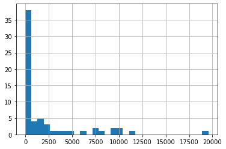

```python
df_company['trips_amount'].hist(bins=30)
plt.show()
```

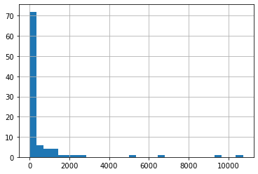

```python
df_trips['average_trips'].hist(bins=30)
plt.show()
```

```python
#statistical summary for categorical variables for df_company
df_company.describe(include=['object'])
```

|  | company_name |
| --- | --- |
| count | 64 |
| unique | 64 |
| top | 3620 - 52292 David K. Cab Corp. |
| freq | 1 |

```python
#statistical summary for categorical variables for df_trips
df_trips.describe(include=['object'])
```

|  | dropoff_location_name |
| --- | --- |
| count | 94 |
| unique | 94 |
| top | Douglas |
| freq | 1 |

# top 10 neighborhoods

```python
#nlargest method for defining top 10 neighborhoods
top_10_neighborhoods = df_trips.nlargest(10,['average_trips'])
top_10_neighborhoods
```

|  | dropoff_location_name | average_trips |
| --- | --- | --- |
| 0 | Loop | 10727.466667 |
| 1 | River North | 9523.666667 |
| 2 | Streeterville | 6664.666667 |
| 3 | West Loop | 5163.666667 |
| 4 | O'Hare | 2546.900000 |
| 5 | Lake View | 2420.966667 |
| 6 | Grant Park | 2068.533333 |
| 7 | Museum Campus | 1510.000000 |
| 8 | Gold Coast | 1364.233333 |
| 9 | Sheffield & DePaul | 1259.766667 |

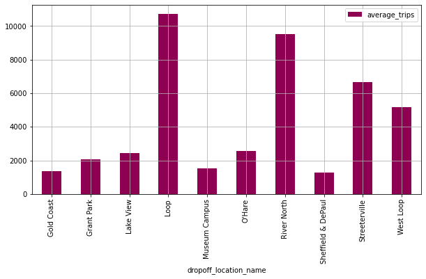

```python
#visualizing number of trips to locations
(top_10_neighborhoods.groupby('dropoff_location_name')
 .agg({'average_trips': sum})
 .plot(y='average_trips', kind='bar', grid=True, figsize=(10,5), cmap='PiYG')
)
plt.show()
```

Loop and River North are the mos popular destinations for getting there by taxi, the rest are leaders lagging behind.

# graph: taxi companies and number of rides

```python
#Ranging the companies by the number of trips
ranged_companies = df_company.groupby('company_name')['trips_amount'].max().sort_values(ascending=False).reset_index()
ranged_companies
```

|  | company_name | trips_amount |
| --- | --- | --- |
| 0 | Flash Cab | 19558 |
| 1 | Taxi Affiliation Services | 11422 |
| 2 | Medallion Leasin | 10367 |
| 3 | Yellow Cab | 9888 |
| 4 | Taxi Affiliation Service Yellow | 9299 |
| ... | ... | ... |
| 59 | 2733 - 74600 Benny Jona | 7 |
| 60 | 4053 - 40193 Adwar H. Nikola | 7 |
| 61 | 5874 - 73628 Sergey Cab Corp. | 5 |
| 62 | 2241 - 44667 - Felman Corp, Manuel Alonso | 3 |
| 63 | 3556 - 36214 RC Andrews Cab | 2 |

64 rows × 2 columns

```python
#counting z-score for taxi trips to define distribution and to range the companies
df_company['trips_z']=(df_company['trips_amount']-df_company['trips_amount'].mean())/df_company['trips_amount'].std()
df_company.head()
```

|  | company_name | trips_amount | trips_z |
| --- | --- | --- | --- |
| 0 | Flash Cab | 19558 | 4.567445 |
| 1 | Taxi Affiliation Services | 11422 | 2.433306 |
| 2 | Medallion Leasin | 10367 | 2.156570 |
| 3 | Yellow Cab | 9888 | 2.030925 |
| 4 | Taxi Affiliation Service Yellow | 9299 | 1.876425 |

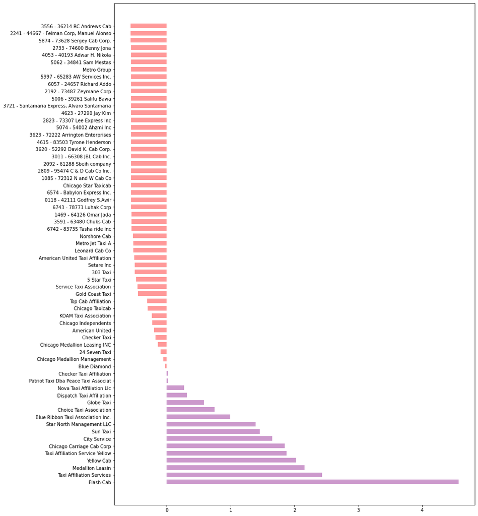

```python
#distinguishing z-score by colors: red for negative values, blue for positive ones
df_company['colors'] = ['red' if x<0 else 'purple' for x in df_company['trips_z']]
df_company['colors']

plt.figure(figsize=(14,20))
plt.hlines(y=df_company.company_name, xmin=0, xmax=df_company.trips_z, colors=df_company.colors, alpha=0.4, linewidth=10)
plt.show()
```

The graph clearly shows that the most successful and popular taxi companies in Chicago as of November 2017 with number of trips above average are to the right (in purple) and less successful are to the left (in red) of the chart.

```python
#Geting the top 16 popular taxi companies marked in purple in previous chatrt
top_16_companies = df_company.nlargest(16,['trips_amount'])
top_16_companies
```

|  | company_name | trips_amount | trips_z | colors |
| --- | --- | --- | --- | --- |
| 0 | Flash Cab | 19558 | 4.567445 | purple |
| 1 | Taxi Affiliation Services | 11422 | 2.433306 | purple |
| 2 | Medallion Leasin | 10367 | 2.156570 | purple |
| 3 | Yellow Cab | 9888 | 2.030925 | purple |
| 4 | Taxi Affiliation Service Yellow | 9299 | 1.876425 | purple |
| 5 | Chicago Carriage Cab Corp | 9181 | 1.845473 | purple |
| 6 | City Service | 8448 | 1.653201 | purple |
| 7 | Sun Taxi | 7701 | 1.457257 | purple |
| 8 | Star North Management LLC | 7455 | 1.392729 | purple |
| 9 | Blue Ribbon Taxi Association Inc. | 5953 | 0.998742 | purple |
| 10 | Choice Taxi Association | 5015 | 0.752697 | purple |
| 11 | Globe Taxi | 4383 | 0.586919 | purple |
| 12 | Dispatch Taxi Affiliation | 3355 | 0.317266 | purple |
| 13 | Nova Taxi Affiliation Llc | 3175 | 0.270050 | purple |
| 14 | Patriot Taxi Dba Peace Taxi Associat | 2235 | 0.023481 | purple |
| 15 | Checker Taxi Affiliation | 2216 | 0.018497 | purple |

```python
top_taxi = top_16_companies.company_name.tolist()
df_company['company_name_tree'] = [x if x in top_taxi else 'others' for x in df_company['company_name']]
df_company['company_name_tree'].value_counts()
```

```
others                                  48
Yellow Cab                               1
Taxi Affiliation Services                1
Nova Taxi Affiliation Llc                1
Taxi Affiliation Service Yellow          1
Choice Taxi Association                  1
Star North Management LLC                1
City Service                             1
Dispatch Taxi Affiliation                1
Globe Taxi                               1
Chicago Carriage Cab Corp                1
Checker Taxi Affiliation                 1
Flash Cab                                1
Medallion Leasin                         1
Blue Ribbon Taxi Association Inc.        1
Sun Taxi                                 1
Patriot Taxi Dba Peace Taxi Associat     1
Name: company_name_tree, dtype: int64
```

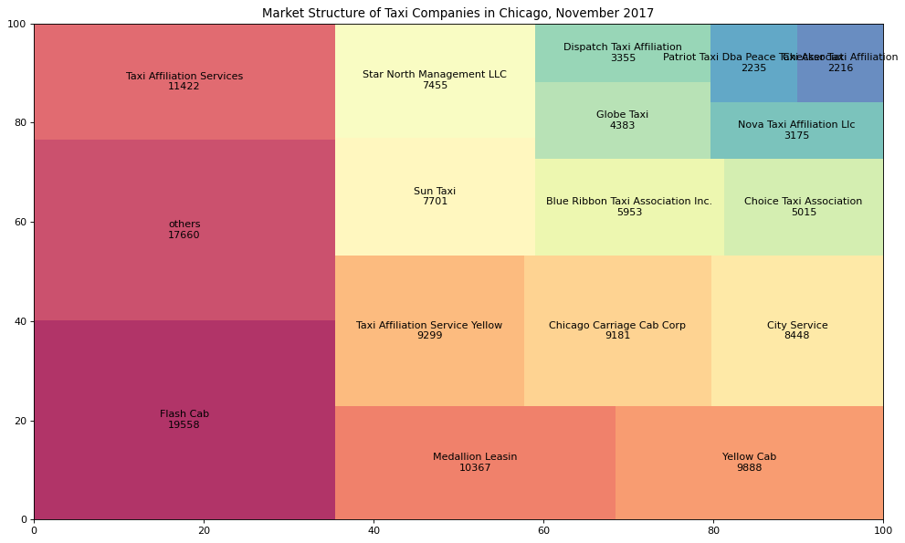

```python
# General market view from the total sales point of view
df_taxi_tree = df_company[['company_name_tree', 'trips_amount']].groupby('company_name_tree').sum().sort_values(by='trips_amount', ascending=False).reset_index()
df_taxi_tree=df_taxi_tree[df_taxi_tree['trips_amount']!=0]

sizes=df_taxi_tree.trips_amount.values.tolist()
labels = df_taxi_tree.apply(lambda x: str(x[0]) + "\n" + str(round(x[1])) , axis=1)


colors = [plt.cm.Spectral(i/float(len(labels))) for i in range(len(labels))]

# Draw Plot
plt.figure(figsize=(15,9), dpi= 80)
squarify.plot(sizes=sizes, label=labels, color=colors, alpha=.8)

# Decorate
plt.title('Market Structure of Taxi Companies in Chicago, November 2017')
#plt.axis('off')
plt.show()
```

The graphs show that Flash Cab is an undisputable leader on Chicago market with the market share twice as much as his closest competitor, Taxi Affiliation Services. The rest top 8 market companies have very close market shares without any distinct leaders among them. Then we see a slight gap and another group of 6 leaders closing the top.

# graph: top 10 neighborhoods by number of dropoffs

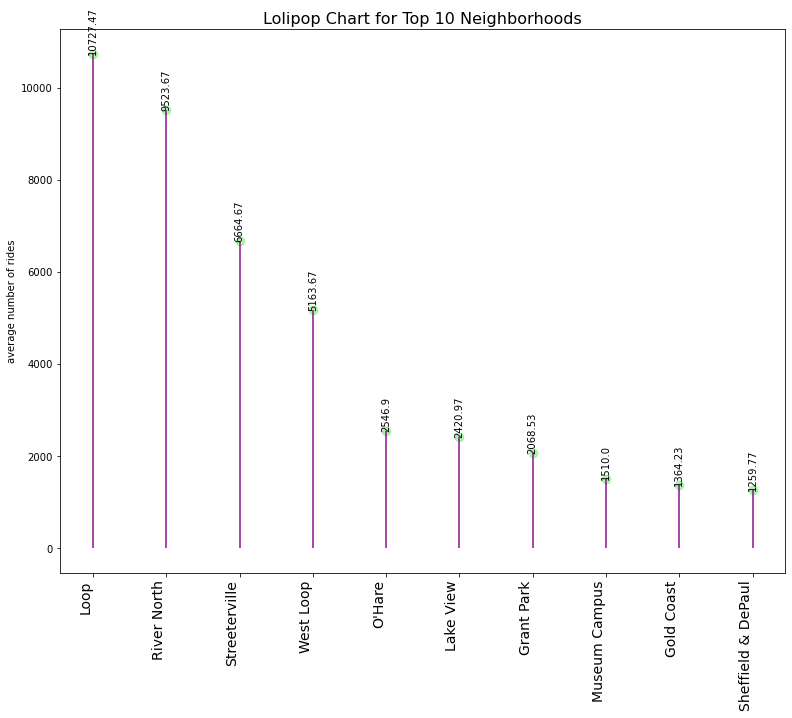

```python
fig,ax=plt.subplots(figsize=(13,10))
ax.vlines(x=top_10_neighborhoods.dropoff_location_name, ymin=0, ymax=top_10_neighborhoods.average_trips, color='purple', alpha=0.7, linewidth=2)
ax.scatter(x=top_10_neighborhoods.dropoff_location_name, y=top_10_neighborhoods.average_trips, s=75, color='lightgreen', alpha=0.7)


ax.set_title('Lolipop Chart for Top 10 Neighborhoods', fontdict={'size':16})
ax.set_ylabel('average number of rides')
ax.set_xticks(top_10_neighborhoods.dropoff_location_name)
ax.set_xticklabels(top_10_neighborhoods.dropoff_location_name,rotation=90, fontdict={'horizontalalignment':'right','size':14})

for  row in top_10_neighborhoods.itertuples():
    ax.text(row.dropoff_location_name, row.average_trips+30,s=round(row.average_trips,2), rotation=90, fontdict={'horizontalalignment':'center','size':10})
```

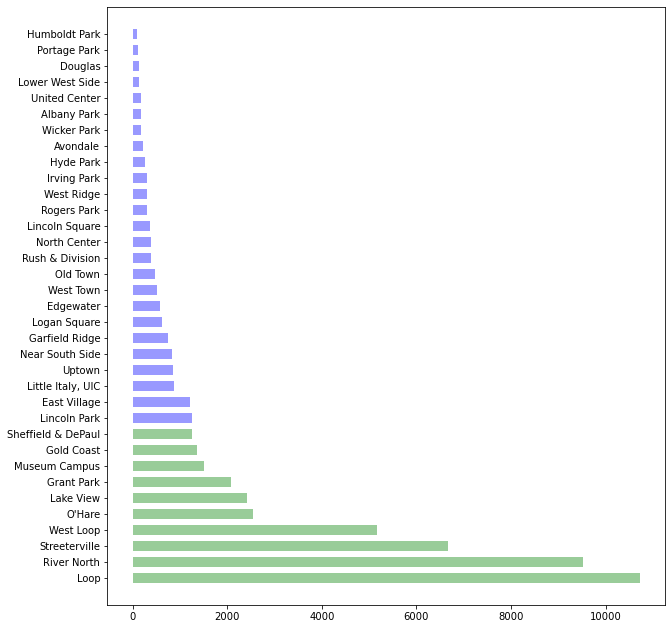

```python
#top 10 locations in comparison to the other 25
top_35_neighborhoods = df_trips.nlargest(35,['average_trips'])
top_35_neighborhoods['colors'] = ['blue' if x<1259 else 'green' for x in top_35_neighborhoods['average_trips']]
top_35_neighborhoods['colors']

plt.figure(figsize=(10,11))
plt.hlines(y=top_35_neighborhoods.dropoff_location_name, xmin=0, xmax=top_35_neighborhoods.average_trips, colors=top_35_neighborhoods.colors, alpha=0.4, linewidth=10)
plt.show()
```

The graph shows top 10 destinations for drop-off (in green), the rest less popular destinations are marked in blue. Clearly people tend to take taxis to parks less often than to pubs and restaurants.

Top 10 neighborhoods vary greatly in the number of drop-offs. The most popular destination was Loop with 10727 drop-offs there, whereas people went to Sheffield & DePaul almost 9-fold less, 1259 drop-offs. The top 4 locations (Loop, River North, Streeterville, and West Loop) leave far behind all the rest of the localities. But all the top spots are very popular destinations with lots of eateries, fancy shops, theaters, dining and nightlife hotspots. O'Hare airport is only on the 5th popular place. Sheffield & DePaul closing the leading 10 is a popular place to live among young professionals, lots of them rent houses there. Based on the most popular destinations for taxi trips we can assume that most of the clients of the taxi companies are tourists and youngsters.